# Prediction of execution of an exercise based on measurements of accelerometers

## Introduction

Human Activity Recognition (HAR) has been an emergent field of research during the recent years. It promises many potential applications such as elderly monitoring, life log systems for monitoring energy expenditure and for supporting weight-loss programs, etc. ([source](http://groupware.les.inf.puc-rio.br/har)). In this piece I deal with a problem where the goal is to predict “how well” an exercise was carried out. The prediction is based on the Weight Lifting Exercises Dataset which contains data about six individuals performing an exercise in different ways (correctly and in four typically mistaken ways). While exercising four sensors (arm, forearm, belt, dumbbell) were active to measure the activity. For this project I can use the predictors derived from these measurements (for further details see the [original paper](http://groupware.les.inf.puc-rio.br/work.jsf?p1=11201)).

The project was carried out in R (with a little help of a nice tool of csv-fingerprint). In order to increase efficiency I use the `doMC` package for parallel computing.

```r
# Load packages
library(doMC)
library(dplyr)
library(tidyr)
library(caret)
library(rattle)
# use parallel computing for training the models
registerDoMC(cores=4)
```

## Exploratory analysis

The data which is used for prediction is quite large. It consists 19,622 observations in 160 variables. The first variables contain general data about the measurement (time, user, etc.), the last one is the classe variable (“A” if the exercise was performed correctly), and the remaining ones are various measurements from the sensors. I split the data into two parts: 60% of the observations will be used to train the models and the remaining 40% will serve as validation data. The final precision of the model is tested on the provided test set.

```r
# Load in the data
#------------------
data <- read.csv("../data/pml-training.csv")
set.seed(20140820)
index.train <- createDataPartition(data$classe, p=0.6)[[1]]
training <- data[index.train, ]        # 60%
validation <- data[-index.train, ]     # 40%
```

As a first step, we can look at the data using the csv-fingerprint tool. As it is only able to deal with relatively small data, I randomly choose 2 percent of the observations from the training data and plug them into the tool. The resulting picture about the types of data can be seen on the figure below. We can see that most of the values are strings (colored by yellow) – even those which are the measurement variables – and there are also many empty cells (colored by dark blue).

```r
training2 <- sample_frac(training, 0.02) %>% arrange(X)

write.table(training2, "../data/training2.csv",
            row.names=FALSE, col.names=FALSE, sep=",")
```

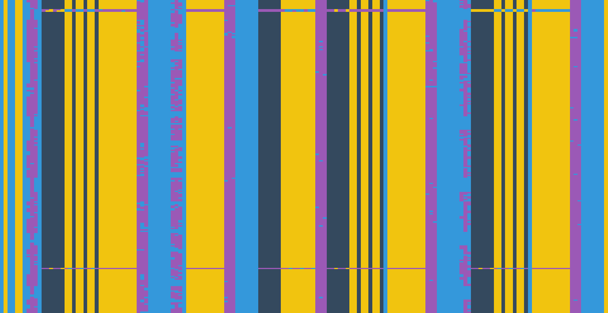

Yellow: string, Blue: empty, Purple: decimal, Lightblue: integer

Based on these observed patterns in the data it is a good idea to reformat the measurement variables coded as string to numeric and to try to detect features with mostly missing values.

```r
# Reformat factor variables as numeric (lot of missing values will be created)
all.data <- list(training=training,
                 validation=validation)

factors <- sapply(all.data$training, is.factor)
# user name, etc, classe should not change
factors[c(1:7, length(factors))] <- FALSE

ToNum <- function(x) {
    num <- suppressWarnings(as.numeric(as.character(x)))
}
all.data$training[, factors] <- lapply(all.data$training[factors], ToNum)
all.data$validation[, factors] <- lapply(all.data$validation[factors], ToNum)
```

```r
# Check missing patterns
Mode <- function(x) {
    ux <- unique(x)
    ux[which.max(tabulate(match(x, ux)))]
}
basevariables <- "^(roll_|pitch_|yaw_)(bell|arm|forearm|dumbbell)$"
tb1 <- group_by(training, user_name) %>%
        summarise_each(funs(mean), matches(basevariables))
tb2 <- group_by(training, user_name) %>%
        summarise(Mode(classe))
inner_join(tb1, tb2, by="user_name")
```

```
## Source: local data frame [6 x 11]
##
##   user_name roll_arm pitch_arm yaw_arm roll_dumbbell pitch_dumbbell
## 1    adelmo   -16.05     5.093 -25.624        61.764        -22.902
## 2  carlitos    52.67   -13.395   5.894        28.439          4.329
## 3   charles   -46.48   -12.759 -32.449        -4.422         -8.169
## 4    eurico    90.76    -6.818  45.774         7.034          6.467
## 5    jeremy     0.00     0.000   0.000        61.249        -47.881
## 6     pedro    53.80    -1.384  20.405       -29.561         13.178
## Variables not shown: yaw_dumbbell (dbl), roll_forearm (dbl), pitch_forearm
##   (dbl), yaw_forearm (dbl), Mode(classe) (fctr)
```

However, our goal is to predict the type of the exercise based on the measurements from the movements, which should later apply to other users as well, so it is better not to use the information about the users.

```r
# Ignore variables like timestamp, etc.
all.data <- lapply(all.data, function(x) { select(x, -(1:7)) } )
```

On the plot below we can see that more than half of the measurements are mainly missing (in more than 97.5 percent of the cases). Although I do not really understand the reason why they are missing, it is certainly better not to include these variables in the model building.

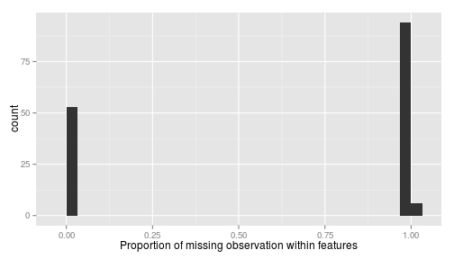

```r
# Try to exclude features which are mostly missing (remains 52, plus classe)
missing.feat <- colMeans(sapply(all.data$training, is.na))
qplot(missing.feat,
      xlab = "Proportion of missing observation within features")
```

```r
index.nonmissing.feat <- which(missing.feat < 0.975)
all.nonmiss <- lapply(all.data, function(x) {select(x, index.nonmissing.feat)})
```

After this simple cleaning process I end up with 52 features whose histograms can be seen on the plot below. They all seem to have normal variation with lots of zeros in some cases.

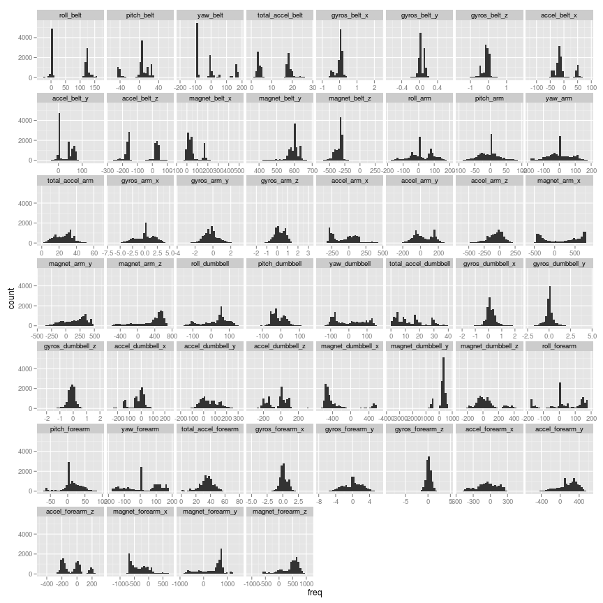

```r
# Plot histograms from variables
variables.to.plot <- select(all.nonmiss$training, -classe) %>%
    gather(x, freq)
ggplot(variables.to.plot, aes(x = freq)) +
    facet_wrap(~x, scales="free_x") +
    geom_histogram()
```

## Model building

First, I build a simple tree model, based only on the base features.

```r
base.data <- all.data$training %>% select(classe, matches(basevariables))
base.tree <- train(classe ~ .,
                   data=base.data,
                   method="rpart")
```

The model's performance on the validation set is quite poor. However, it is still a large improvement compared to the benchmark (we correctly specified the classe in 42 percent of the cases whereas there are 5 classes with close to equal prevalence).

```r
# performance on validation set
mean(predict(base.tree, validation) == validation$classe)
```

```
## [1] 0.4247
```

For the next step I choose to build a more complicated model on the same set of variables, a random forest. This results in a huge improvement, it is able to predict more than 93% of the cases correctly.

```r
base.forest <- train(classe ~ .,
                     data=base.data,
                     method="rf")
# performance on validation set
mean(predict(base.forest, validation) == validation$classe)
```

```
## [1] 0.9318
```

If I run the same model (random forest) on all of my (cleaned) data, I get a further improvement in accuracy reaching 99% on the validation set. From the confusion matrix we can also tell that the best (balanced) accuracy is reached for the classe “A” which denotes the correctly executed exercise. As I suspect that to differentiate between correct and incorrect exercise is more important than to differentiate between different types of incorrect ones, this is good news.

```r
# All non-missing, random forest, all
nonmiss.forest.all <- train(classe ~ .,
                            data=all.nonmiss$training,
                            method="rf")
# performance on validation set
confusionMatrix(predict(nonmiss.forest.all, validation),
                validation$classe)
```

```
## Confusion Matrix and Statistics
##
##           Reference
## Prediction    A    B    C    D    E
##          A 2230    9    0    0    0
##          B    1 1506    7    1    1
##          C    0    2 1356   19    1
##          D    0    1    5 1265    2
##          E    1    0    0    1 1438
##
## Overall Statistics
##
##                Accuracy : 0.993
##                  95% CI : (0.991, 0.995)
##     No Information Rate : 0.284
##     P-Value [Acc > NIR] : <2e-16
##
##                   Kappa : 0.992
##  Mcnemar's Test P-Value : NA
##
## Statistics by Class:
##
##                      Class: A Class: B Class: C Class: D Class: E
## Sensitivity             0.999    0.992    0.991    0.984    0.997
## Specificity             0.998    0.998    0.997    0.999    1.000
## Pos Pred Value          0.996    0.993    0.984    0.994    0.999
## Neg Pred Value          1.000    0.998    0.998    0.997    0.999
## Prevalence              0.284    0.193    0.174    0.164    0.184
## Detection Rate          0.284    0.192    0.173    0.161    0.183
## Detection Prevalence    0.285    0.193    0.176    0.162    0.184
## Balanced Accuracy       0.999    0.995    0.994    0.991    0.998
```

In the following, I build two additional models: (1) a random forest which uses only the principal components of the variables which explain 90 percent of the total variance and (2) and a generalized boosted model using the `gbm` method of the `caret` package.

```r
# All non-missing, random forest, pca 90%
nonmiss.forest.pca <- train(classe ~ .,
                            data=all.nonmiss$training,
                            method="rf",
                            preProcess="pca",
                            trControl=trainControl(preProcOptions=(thresh=0.9)))
# performance on validation set
mean(predict(nonmiss.forest.pca, validation) == validation$classe)
```

```
## [1] 0.9716
```

```r
# All non-missing, boosting
nonmiss.boost <- train(classe ~ .,
                       data=all.nonmiss$training,
                       method="gbm")
```

```r
# performance on validation set
mean(predict(nonmiss.boost, validation) == validation$classe)
```

```
## [1] 0.9637
```

We can see that the random forest models perform better than the boosted one, and that the one which use all of the variables perform better than the preprocessed one (measured on the validation set). The random forest without principal component preprocessing reaches an accuracy of 99 percent. The other two models are slightly worse, but still very good: they predict the classe correctly in 96-97 percent of the cases. As ensembling different models together usually promises some accuracy gain (if there is at least some indepence between the models) I stack together the last three models by using the random forest method on the predictions.

```r
df.predicted <- data.frame(
    pred.forest=predict(nonmiss.forest.pca, all.nonmiss$training),
    pred.forest.pca=predict(nonmiss.forest.all, all.nonmiss$training),
    pred.boost=predict(nonmiss.boost, all.nonmiss$training),
    classe=all.nonmiss$training$classe
)
stacked <- train(classe ~ .,
                 data=df.predicted,
                 method="rf")
# performance on validation set
df.predicted.validation <- data.frame(
    pred.forest=predict(nonmiss.forest.pca, all.nonmiss$validation),
    pred.forest.pca=predict(nonmiss.forest.all, all.nonmiss$validation),
    pred.boost=predict(nonmiss.boost, all.nonmiss$validation),
    classe=all.nonmiss$validation$classe
)
mean(predict(stacked, df.predicted.validation) == validation$classe)
```

```
## [1] 0.9879
```

The performance of the stacked model is an accuracy of about 98 percent. The fact that it is slightly below the bigger random forest model might be due to the similarity of the models which were stacked together and to the already really high accuracy of one of the models. I think that 99 percent accuracy on the validation set is quite good so I choose the random forest model without prepocessing to be my final model. Its performance of a completely new data (like on the test set) might be slightly worse, but since I did not really do any fine-tuning based on the validation set results I do not expect this drop to matter.

## Conclusion

```r
testing <- read.csv("../data/pml-testing.csv")
# apply the same transformations as before
testing[, factors] <- lapply(all.data$validation[factors], ToNum)
testing <- select(testing, -(1:7))
testing <- select(testing, index.nonmissing.feat)
answers <- predict(nonmiss.forest.all, testing)
```